# Homework

## Statistics warm-up

Consider a random variable $X$ with a probability density function

$$f(x) = \frac{c}{\sqrt{x(b-x)}}, \quad 0<x<b.$$
where $c$ is a normalising constant and $b$ is a parameter.

- Find $c$ such that the probability density function is valid.

*Possible solution:*

We require $\int_0^b f(x)\,dx = 1$. Use the subsitution $u=\sqrt{x}$, so $2u\,du = dx$ and $\sqrt{b-x} = \sqrt{b-u^2}$. Then

$$1 = \int_0^{\sqrt{b}} c \frac{1}{u\sqrt{b-u^2}}\cdot2u\,du = 2c \int_0^{\sqrt{b}} \frac{du}{\sqrt{b-u^2}} = 2c \sin^{-1}\left(u/\sqrt{b}\right)\bigg|_0^{\sqrt{b}} = 2c(\sin^{-1}(1) - \sin^{-1}(0)) = 2c(\pi/2) = c\pi$$
so $c=\frac{1}{\pi}$.

- Find the corresponding cumulative distribution function, $F(x)$ and its inverse $F^{-1}(x)$.

*Possible solution:*

Using the same substitution as above,
$$F(x) = \frac{2}{\pi}\sin^{-1}\left(\sqrt{\frac{x}{b}}\right), \quad 0<x<b.$$

The inverse is obtained by solving $x = F^{-1}(u)$, giving
$$F^{-1}(x) = b \sin^2\left(\frac{\pi x}{2}\right).$$

- Describe a procedure to generate samples distributed according to $X$, given a set of uniformly distributed samples $u_1,\dots,u_n$.

*Possible solution:*

Use the inverse probability transform. Indeed, if $u$ is uniformly distributed, then $x = F^{-1}(u)$ will be distributed according to $X$.
$$x = F^{-1}(u) = b \sin^2\left(\frac{\pi u}{2}\right).$$

- Set the seed to 42 and generate 1,000 samples distributed according to $X$ using 1,000 uniformly distributed samples, with $b=5$. Plot a histogram of the resulting samples.

*Possible solution:*

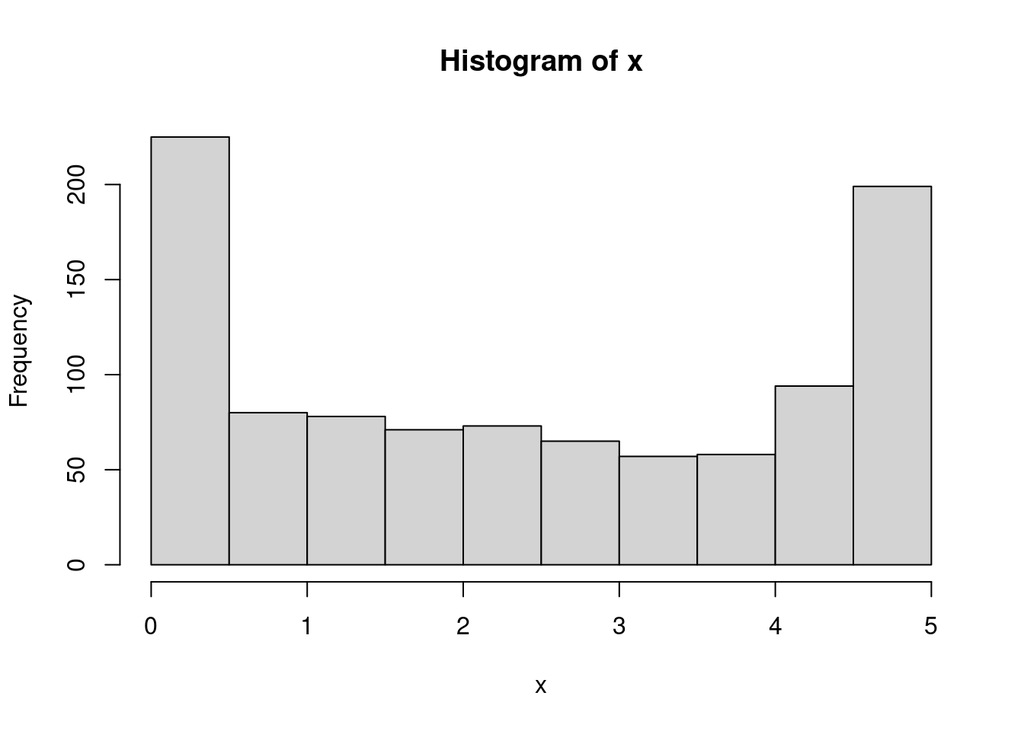

```r
set.seed(42)
u <- runif(1000)
x <- 5 * (sin(pi*u/2))^2
hist(x)
```

- Assume that we have a set of samples $X_1,\dots,X_n$ which are i.i.d. as $X$ with $b$ unknown. Find the log-likelihood function for the parameter $b$, $\ell(b;x_1,\dots,x_n)$ and find its derivative with respect to $b$, $\frac{d\ell}{db}$.

*Possible solution:*

For i.i.d. samples, the likelihood is the product of the densities evaluated at the sample points.

$$\ell(b; x_1,\dots,x_n) = \log \prod_{i=1}^n \frac{1}{\pi\sqrt{x_i(b-x_i)}} = -n\log(\pi) - \frac{1}{2}\sum_{i=1}^n (\log{x_i} + \log(b-x_i)).$$

The derivative with respect to $b$ is given by
$$\frac{d\ell}{db} = -\frac{1}{2} \sum_{i=1}^n \frac{1}{b-x_i}.$$

- Based on the likelihood, or otherwise, give a statistic based on $X_1,\dots,X_n$ which is a reasonable estimator for the unknown parameter $b$. Explain your choice.

*Possible solution:*

Since $x_i < b$, $b-x_i > 0$ and so the derivative is always negative. That is, the log-likelihood is always decreasing. The value of $b$ should then be chosen as $\max_{i=1,\dots,n}\{x_i\}$ in order to maximise the likelihood.

- The file `samples.rds` contains samples $X_1,\dots,X_n$ distributed according to $X$. Report the estimated value of $\hat{b}$ based on those samples.

*Possible solution:*

```r
samples <- readRDS('samples.rds')
b_hat <- max(samples)
b_hat
```

```
## [1] 85.19952
```

## Arrays

You are given a multi-dimensional array `data.rds`. It contains penetrance curves for various cancers and genes. In simple terms, penetrances are how likely one will develop a cancer given that they have a certain corresponding gene mutation. Other variables in `data` describe different sub-populations.

- Read in the data and give the dimensions of the array.

*Possible solution:*

```r
data <- readRDS('data.rds')
str(data)
```

```
##  num [1:18, 1:26, 1:8, 1:2, 1:94, 1:2] 3.98e-05 2.80e-07 0.00 5.00e-08 0.00 ...
##  - attr(*, "dimnames")=List of 6
##   ..$ Cancer   : chr [1:18] "Brain" "Breast" "Cervical" "Colorectal" ...
##   ..$ Gene     : chr [1:26] "APC" "ATM" "BARD1" "BMPR1A" ...
##   ..$ Race     : chr [1:8] "All_Races" "AIAN" "Asian" "Black" ...
##   ..$ Sex      : chr [1:2] "Female" "Male"
##   ..$ Age      : chr [1:94] "1" "2" "3" "4" ...
##   ..$ PenetType: chr [1:2] "Net" "Crude"
```

The data is $18 \times 26 \times 8 \times 2 \times 94 \times 2$.

- Plot the net and crude penetrance curves (probability versus age) for any female for the BRCA2 and breast cancer.

*Possible solution:*

First subset the relevant data.

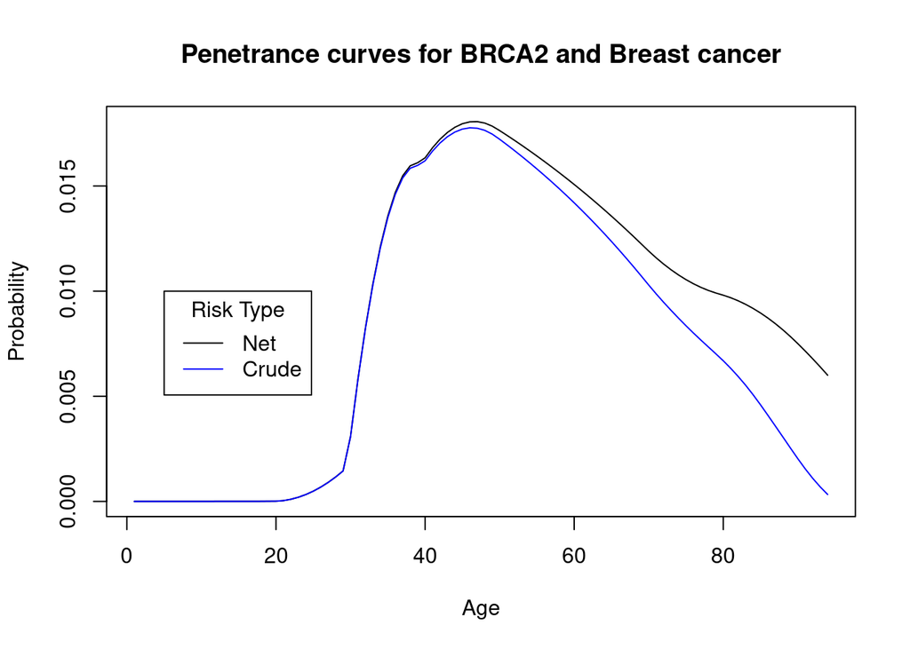

```r
subset <- data["Cancer" = "Breast", "Gene" = "BRCA2", "Race" = "All_Races", "Sex" = "Female", ,]
x <- as.integer(row.names(subset))
y1 <- subset[, 1]
y2 <- subset[, 2]
plot(x, y1, type = "l", xlab = "Age", ylab = "Probability")
lines(x, y2, col = "blue")
title("Penetrance curves for BRCA2 and Breast cancer")
legend(x = 5, y = 0.01, legend = c("Net", "Crude"), title = "Risk Type", col = c("black", "blue"), lty = c(1, 1))
```

- What is the net probability that an Asian male aged 50 will develop colorectal cancer in the next 10 years given that he has tested positive for a deleterious PALB2 mutation but is otherwise disease free?

*Possible solution:*

```r
asian_male <- data["Cancer" = "Colorectal", "Gene" = "PALB2", "Race" = "Asian", "Sex" = "Male", ,"PenetType" = "Net"][50:60]
prob <- sum(asian_male)
prob
```

```
## [1] 0.00812721
```

## Family pedigrees

Read in the `.rdata` file `pedigree.rda`. Each `data.frame` represents a family. Each individual is uniquely identified by the first column called `ID`. Their sex is coded as `0` for females and `1` for males. Individuals’ mother and father are indicated in the `MotherID` and `FatherID` columns. A value of `NA` in these columns means that this person is a so-called ‘founder’ or that a certain parent is missing. In this exercise there are two main goals. The first is to count how many nuclear families there are in a certain pedigree. A nuclear family is defined as the set of two parents and all of their children. The second goal is to correct any errors in the data with respect to `race` column.

A visualisation of `fam10` is shown below to illustrate the family structure but will not be used further.

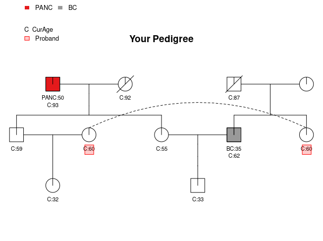

In the next two exercises, you are encouraged to modularise and comment on your code.

- Write an R function(s) to count the number of unique nuclear families there are in a certain pedigree.

*Possible solution:*

```r
load("pedigree.rda")
```

```r
get_nuclear_fams <- function(pedigree) {
  # Get the non-founders of the pedigree with their ID/parent columns
  trio_IDs <- pedigree[!is.na(pedigree$MotherID ) | !is.na(pedigree$FatherID),
                       c("ID", "MotherID", "FatherID")]

  # Check that there is actually a family and not just disconnected singles or other structures
  if (nrow(trio_IDs) == 0) {
    rlang::inform("No nuclear family detected here. Returning empty data frame.", level = "empty")
    return(data.frame())
  }

  # Aggregate them by mother and father ID, using the concatenation function c
  nuclear_IDs <- aggregate(trio_IDs, by = list(trio_IDs$MotherID, trio_IDs$FatherID), FUN = c, simplify = FALSE)

  # Remove the duplicated mother and father IDs
  nuclear_IDs$MotherID <- sapply(nuclear_IDs$MotherID, unique)
  nuclear_IDs$FatherID <- sapply(nuclear_IDs$FatherID, unique)

  return(nuclear_IDs)
}

count_nuclear_fams <- function(pedigree) {
  # Return the number of rows of the nuclear families
  return(nrow(get_nuclear_fams(pedigree)))
}
```

- Write an R function(s) which corrects the race column of a given pedigree according to the following rules: children of parents with the same race should the same race as their parents, whilst children of mixed raced parents should have their race as the default “All_Races”. The race of founders does not change. The list of possible races is given in `dimnames(data)$Race`.

*Possible solution:*

```r
fix_race_data <- function(pedigree) {
  # Get the nuclear families
  nuclear_fams <- get_nuclear_fams(pedigree)

  # If there are nuclear fams, go through each of them
  if (nrow(nuclear_fams) > 0) {
    for (i in 1:nrow(nuclear_fams)) {

      # Get the parent and children IDs
      parents <- pedigree$ID[unlist(pedigree$ID %in% nuclear_fams[i, c("MotherID", "FatherID")])]
      children <- nuclear_fams[i, "ID"][[1]]

      # Get the parent's races and children's races
      parents_races <- pedigree[pedigree$ID %in% parents, "race"]
      # children_races <- pedigree[pedigree$ID %in% children, "race"]

      # Check whether parents' race are the same or not
      if (length(unique(parents_races)) == 1) {
        # Parents are the same race so force all children to have that race
        # Children might already have that race
        pedigree[["race"]][pedigree$ID %in% children] <- unique(parents_races)
      } else if (length(unique(parents_races)) > 1) {
        # For children to have "All_Races"
        pedigree[["race"]][pedigree$ID %in% children] <- "All_Races"
      }
    }
  }

  return(pedigree)
}
```

- Report the number of nuclear families in `fam10` and print `fam10` with its corrected race column.

*Possible solution:*

There are 4 nuclear families in `fam10`. Everyone but the founders should be changed to “All_Races” so we should get

```r
fam10_corrected <- fix_race_data(fam10)
fam10_corrected$race
```

```
##  [1] "Black"     "Asian"     "White"     "WNH"       "All_Races" "All_Races"
##  [7] "All_Races" "All_Races" "All_Races" "All_Races"
```

- What could be some problems or consequences of the race correction rules as stated above? Suggest an alternative which may produce more ‘accurate’ results.

*Possible solution:*

If cancer or gene mutation risk varies a lot with race, then the above procedure will generally lead to information loss within mixed race families. ‘All_Races’ will tend to propagate to the lower generations in this case. Other correction rules could be made in order to give more accurate labelling to mixed race children - for example thresholds (percentages) could be used to determine whether someone will then be labelled as one race or another, depending on not only the parents but also grandparents and higher generations. A validation procedure should be conducted to see if this method is better at capturing risk for certain purposes (e.g. genetic counselling) or not.

Considering the problem purely from a data input error perspective, if all the children have the same race, with one of the parents erroneously labelled, a bottom-up approach could be considered as well. It may make sense to run through a top-down and bottom-up approach to handling erroneous data. This raises another question of ‘ground-truth’ - it may not always be clear to spot an error in the labelling since, for example, all the races are randomly assigned, the resulting race column would be uninformative and it would probably be better to set them all to ‘All_Races’. Data quality could be inferred to be more accurate from the ‘proband’ (not mentioned in the problem) outward.

- Write an alternative to the above function where the rule changes to the following: if one parent is “All_Races”, with the other parent another race, their children will inherit the latter race. Discuss the implications of such a rule.

*Possible solution:*

```r
adjust_races_data <- function(pedigree) {
  # Get the nuclear families
  nuclear_fams <- get_nuclear_fams(pedigree)

  # If there are nuclear fams, go through each of them
  if (nrow(nuclear_fams) > 0) {
    for (i in 1:nrow(nuclear_fams)) {

      # Get the parent and children IDs
      parents <- pedigree$ID[unlist(pedigree$ID %in% nuclear_fams[i, c("MotherID", "FatherID")])]
      children <- nuclear_fams[i, "ID"][[1]]

      # Get the parent's races and children's races
      parents_races <- pedigree[pedigree$ID %in% parents, "race"]
      # children_races <- pedigree[pedigree$ID %in% children, "race"]

      # Check whether parents' race are the same or not
      if (length(unique(parents_races)) == 1) {
        # Parents are the same race so force all children to have that race
        # Children might already have that race
        pedigree[["race"]][pedigree$ID %in% children] <- unique(parents_races)
      } else if (length(unique(parents_races)) == 2 && !("All_Races" %in% parents_races)) {
        # For children to have "All_Races" - exclude case where All_Races is one of the races
        pedigree[["race"]][pedigree$ID %in% children] <- "All_Races"
      } else if (length(unique(parents_races)) == 2 && "All_Races" %in% parents_races) {
        # Inherit from the other parent
        pedigree[["race"]][pedigree$ID %in% children] <- setdiff(parents_races, "All_Races")
      }
    }
  }

  return(pedigree)
}
```

There is, in general, less information loss in this case since we are using the data for one parent at least.

- Report the number of nuclear families in each of the pedigrees `fam50`, `fam75` and `fam100`. Then compare the resulting race columns between the two versions. Fill in the following table with the corrected races of the individualis listed below. Discuss the results.

| Individual | fam50_v1 | fam50_v2 | fam75_v1 | fam75_v2 | fam100_v1 | fam100_v2 |
| --- | --- | --- | --- | --- | --- | --- |
| 12 |  |  |  |  |  |  |
| 15 |  |  |  |  |  |  |
| 46 |  |  |  |  |  |  |

*Possible solution:*

```r
count_nuclear_fams(fam50)
```

```
## [1] 10
```

```r
count_nuclear_fams(fam75)
```

```
## [1] 18
```

```r
count_nuclear_fams(fam100)
```

```
## [1] 26
```

```r
fixed_fam50 <- fix_race_data(fam50)
fixed_fam75 <- fix_race_data(fam75)
fixed_fam100 <- fix_race_data(fam100)

adjusted_fam50 <- adjust_races_data(fam50)
adjusted_fam75 <- adjust_races_data(fam75)
adjusted_fam100 <- adjust_races_data(fam100)
```

| Individual | fam50_v1 | fam50_v2 | fam75_v1 | fam75_v2 | fam100_v1 | fam100_v2 |
| --- | --- | --- | --- | --- | --- | --- |
| 12 | All_Races | Hispanic | All_Races | All_Races | All_Races | Black |
| 15 | All_Races | Hispanic | All_Races | All_Races | All_Races | Black |
| 46 | AIAN | AIAN | AIAN | AIAN | Asian | Asian |

The second version is ‘less conservative’ overall, converting less of the entries to All_Races, as expected. Once again, a validation procedure should be conducted to see if these methods are appropriate for the risks they are trying to estimate.